# Federated queries: enriching PlantMetWiki metabolites with Wikidata and PubChem

## Part 6 — Figures for the federation section

Three publication figures illustrating the value of federated queries:

**Figure A:** Knowledge integration hub — theobromine at the centre, PlantMetWiki data on one side, external databases on the other; shows what each resource contributes.

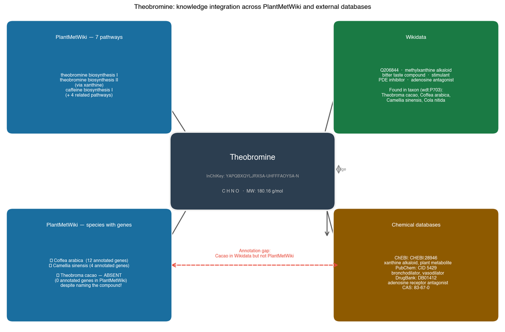

```
Saved: theobromine_knowledge_hub
```

```python
# ─────────────────────────────────────────────────────────────────────────────
# Figure A: Knowledge integration hub for theobromine
# ─────────────────────────────────────────────────────────────────────────────
import matplotlib.patches as mpatches
import matplotlib.patheffects as pe

fig, ax = plt.subplots(figsize=(12, 8))
ax.set_xlim(0, 12); ax.set_ylim(0, 8); ax.axis('off')

def rounded_box(ax, x, y, w, h, color, text, title=None, fontsize=8):
    rect = mpatches.FancyBboxPatch((x, y), w, h,
        boxstyle="round,pad=0.15", facecolor=color, edgecolor='white', linewidth=1.5, zorder=2)
    ax.add_patch(rect)
    if title:
        ax.text(x + w/2, y + h - 0.22, title,
                ha='center', va='top', fontsize=9, fontweight='bold', color='white', zorder=3)
    ax.text(x + w/2, y + h/2 - (0.2 if title else 0), text,
            ha='center', va='center', fontsize=fontsize, color='white',
            multialignment='center', zorder=3)

def arrow(ax, x1, y1, x2, y2, color='#555'):
    ax.annotate('', xy=(x2,y2), xytext=(x1,y1),
                arrowprops=dict(arrowstyle='->', color=color, lw=1.5),
                zorder=1)

# ── Center: theobromine ──────────────────────────────────────────────────────
cx, cy, cw, ch = 4.2, 3.2, 3.6, 1.6
rect_c = mpatches.FancyBboxPatch((cx, cy), cw, ch,
    boxstyle="round,pad=0.2", facecolor='#2c3e50', edgecolor='#f0f0f0', linewidth=2.5, zorder=4)
ax.add_patch(rect_c)
ax.text(cx+cw/2, cy+ch*0.72, 'Theobromine', ha='center', va='center',
        fontsize=13, fontweight='bold', color='white', zorder=5)
ax.text(cx+cw/2, cy+ch*0.42, 'InChIKey: YAPQBXQYLJRXSA-UHFFFAOYSA-N',
        ha='center', va='center', fontsize=7, color='#aaa', zorder=5, style='italic')
ax.text(cx+cw/2, cy+ch*0.18, 'C₇H₈N₄O₂  ·  MW: 180.16 g/mol',
        ha='center', va='center', fontsize=7.5, color='#ccc', zorder=5)

# ── Top-left: PlantMetWiki pathways ─────────────────────────────────────────
rounded_box(ax, 0.2, 5.1, 3.7, 2.6, '#1a6e9f',
    'theobromine biosynthesis I\ntheobromine biosynthesis II\n(via xanthine)\ncaffeine biosynthesis I\n(+ 4 related pathways)',
    title='PlantMetWiki — 7 pathways', fontsize=8)
arrow(ax, 3.9, 5.8, 4.5, 4.8)

# ── Bottom-left: Species (gap!) ──────────────────────────────────────────────
rounded_box(ax, 0.2, 0.3, 3.7, 2.6, '#1a6e9f',
    '✓ Coffea arabica  (12 annotated genes)\n✓ Camellia sinensis (4 annotated genes)\n\n✗ Theobroma cacao — ABSENT\n   (0 annotated genes in PlantMetWiki)\n   despite naming the compound!',
    title='PlantMetWiki — species with genes', fontsize=7.5)
arrow(ax, 3.9, 2.1, 4.5, 3.2)

# ── Top-right: Wikidata ──────────────────────────────────────────────────────
rounded_box(ax, 8.1, 5.1, 3.7, 2.6, '#1a7a44',
    'Q206844  ·  methylxanthine alkaloid\nbitter taste compound  ·  stimulant\nPDE inhibitor  ·  adenosine antagonist\n\nFound in taxon (wdt:P703):\nTheobroma cacao, Coffea arabica,\nCamellia sinensis, Cola nitida',
    title='Wikidata', fontsize=7.5)
arrow(ax, 7.8, 4.8, 7.6, 4.8)  # from center to wikidata

# ── Bottom-right: Other DBs ──────────────────────────────────────────────────
rounded_box(ax, 8.1, 0.3, 3.7, 2.6, '#8e5a00',
    'ChEBI: CHEBI:28946\n   xanthine alkaloid, plant metabolite\nPubChem: CID 5429\n   bronchodilator, vasodilator\nDrugBank: DB01412\n   adenosine receptor antagonist\nCAS: 83-67-0',
    title='Chemical databases', fontsize=7.5)
arrow(ax, 7.8, 3.5, 7.8, 2.3)

# ── Connect right panels ─────────────────────────────────────────────────────
arrow(ax, 7.7, 4.8, 8.1, 6.4)   # center → wikidata
arrow(ax, 7.7, 3.4, 8.1, 1.8)   # center → chem DBs

# ── InChIKey bridge label ────────────────────────────────────────────────────
ax.text(7.9, 4.05, 'InChIKey bridge', ha='center', va='center', fontsize=7,
        color='#888', style='italic')
ax.annotate('', xy=(8.08, 4.2), xytext=(8.08, 3.9),
            arrowprops=dict(arrowstyle='<->', color='#888', lw=1.2))

# ── Gap annotation ───────────────────────────────────────────────────────────
ax.annotate('', xy=(4.0, 1.6), xytext=(8.1, 1.6),
            arrowprops=dict(arrowstyle='<->', color='#e74c3c', lw=1.5,
                           linestyle='dashed'))
ax.text(6.05, 1.78, 'Annotation gap:\nCacao in Wikidata but not PlantMetWiki',
        ha='center', va='bottom', fontsize=7.5, color='#e74c3c', fontweight='bold')

ax.set_title('Theobromine: knowledge integration across PlantMetWiki and external databases',
             fontsize=11, fontweight='bold', pad=10)
plt.tight_layout()
plt.savefig('figures/output/figures/theobromine_knowledge_hub.pdf', bbox_inches='tight')
plt.savefig('figures/output/figures/theobromine_knowledge_hub.svg', bbox_inches='tight')
plt.show()
print("Saved: theobromine_knowledge_hub")
```

**Figure A — Knowledge-integration hub (theobromine).** Shows theobromine as the integration point between PlantMetWiki (pathway and gene data, left) and external knowledge databases (Wikidata, ChEBI, PubChem, DrugBank, right). The dashed red arrow highlights the key annotation gap: Wikidata knows theobromine is found in *Theobroma cacao* (chocolate), but PlantMetWiki has no *T. cacao* genes in its theobromine pathway. *How to read it:* this is an example of an inference target that is revealed only by combining PlantMetWiki and Wikidata — neither resource shows the gap on its own.